# Why We Hold the Bible in High Esteem

# Welcome!

- You’re welcome to oure *Department of Bible Studies*

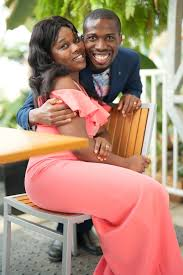

Michael and Mary Agronah, Assistant Professors of Teaching

Figure 1: Teaching Team

# What is an `R` package and when should I make one?

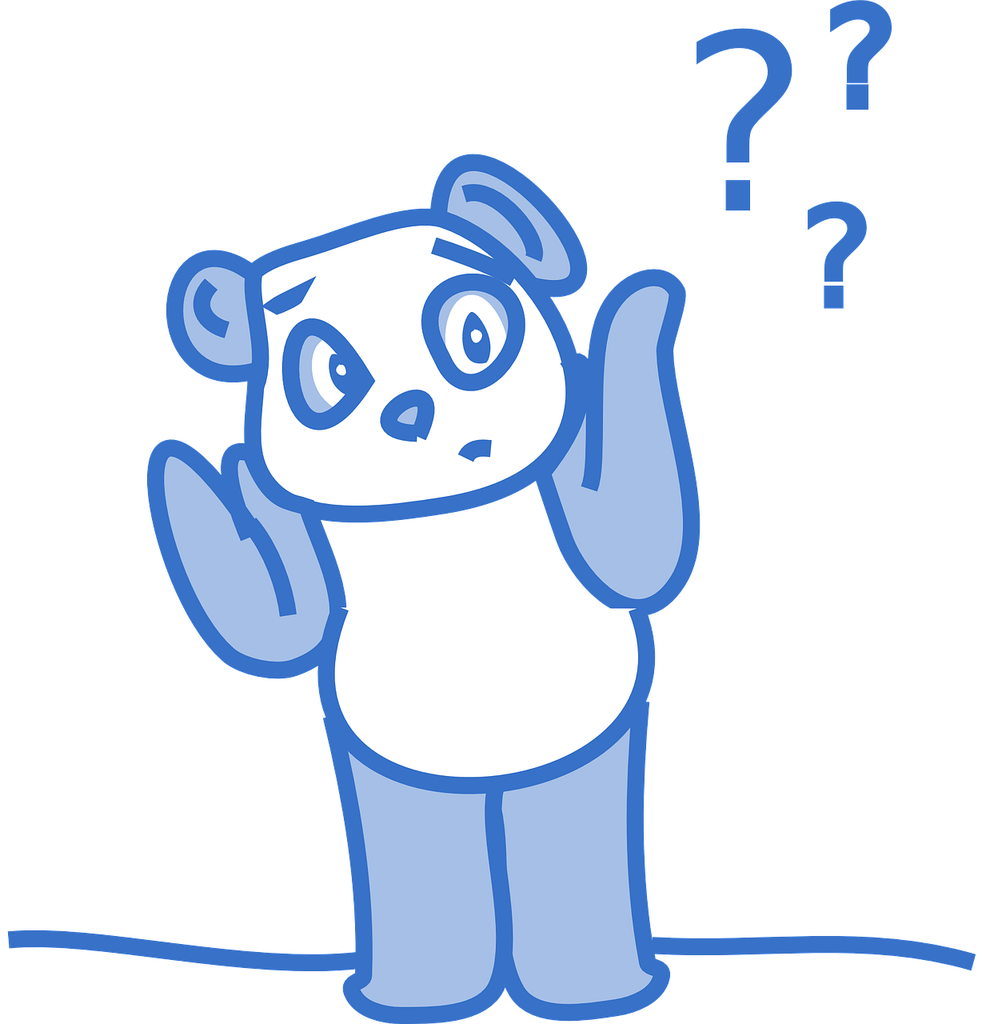

## This question is key!

- An `R` package is a collection of functions, tests, data, compiled code, and standardized documentation
- The reason to create a package is mostly about creating code that should be easier to reuse and share

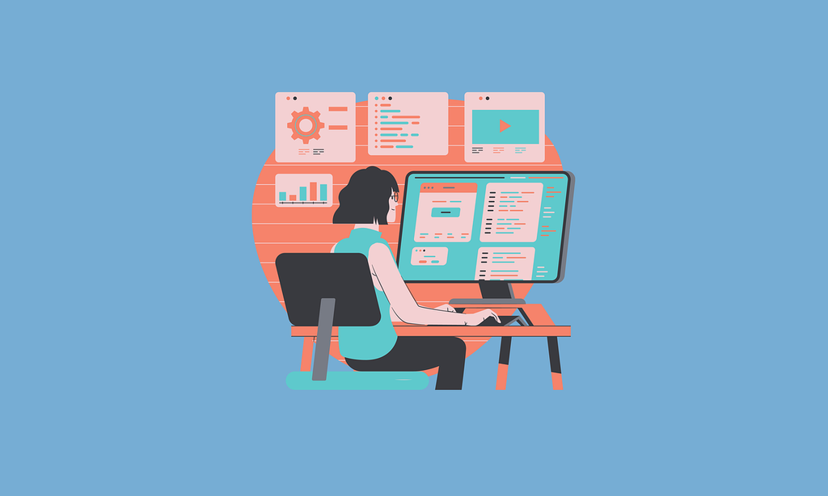

## More specifically…

- `R` packages are created:
  - When your DRY (“Do Not Repeat Yourself) radar goes off
  - When you think your code has general usefulness others could benefit from (this could include future you)
  - When you want to share data (`R` packages in particular are used quite heavily for this)

> **Source:** Lecture notes from [UBC’s **DSCI 310** course (Reproducible and Trustworthy Workflows for Data Science)](https://ubc-dsci.github.io/reproducible-and-trustworthy-workflows-for-data-science/materials/lectures/10-packaging-and-documenting.html#when-to-start-writing-an-r-or-python-package)

## Let’s start with a motivating example

- Suppose that, in many of your analyses, you find yourself repeatedly coding the distribution of observations over the classes (i.e., categories) of a given variable in your dataset
- You find yourself rewriting code, copying and pasting code and/or copying and pasting files containing the code to do this

## Moreover…

- In doing so, you sometimes (or often!) make trivial mistakes
- You wonder whether others doing similar analyses face this problem as well, and want to share your (eventual) solution with others

## Counting observations across classes code example

- The code below is counting how many cars in `mtcars` (composed of 32 observations) have `4`, `6`, and `8` cylinders

```r
library(tidyverse, quietly = TRUE)

mtcars |>
  group_by(cyl) |>
  summarize(count = n()) |>
  rename("class" = cyl)
```

```
# A tibble: 3 × 2
  class count
  <dbl> <int>
1     4    11
2     6     7
3     8    14
```

## Is an `R` package the answer to our pains with how we have been previously trying to reuse our code?

**Yes, it is!**

## Packaging our code

- Allows us to more easily reuse it in many different projects, in a less error-prone way
- Lets others benefit from the code we have written
- Increases our code quality because when packaging we:
  - must modularize our code into functions and write function reference documentation
  - have our code organized in a way that works well with tools for creating tutorials/vignettes, as well as formal code/software testing

## How are `R` packages shared and downloaded?

- `R` packages can be shared and downloaded using code repositories, like GitHub
- We also have the [**Comprehensive R Archive Network (CRAN)**](https://cran.r-project.org) with over 20,000 packages available

> *CRAN is a network of ftp and web servers around the world that store identical, up-to-date, versions of code and documentation for `R`.*

## What will be the workshop topics?

- Development of `R` packages via a toy example
- Introduction to package testing
- Setting up documentation
- Introduction to continuous integration via GitHub Actions
- Sharing and publishing packages on GitHub and CRAN
- Definition of copyright rules
- Choosing the most appropriate license